# R_review_h24076142

Ricky Chyo

2020/5/6

[figure not shown]

很酷的功能

### 因為r並不是我第一個接觸的程式語言(第一個是python)，所以在學r的時候腦袋中就已經有一些寫程式的邏輯了，剩下要學的就剩語法的部分而已，儘管如此，在對語法不熟悉的情況下，只靠程式邏輯邊查語法邊寫r也是挺花時間的。在這裡小小總結一下，我不會在此作業中對於在上學期學到的所有語法進行回顧及複習，而是針對自己較感興趣的部分，以及課程中發現的r與python的不同之處進行說明。

### 學程式一開始學的不外乎是定義變數r及四則運算

```r
a <- c(10 + 3,10 - 3,10 * 3,10 / 3,10 ^ 3,10 %% 3,10 %/% 3) #定義變數可以用<-或是=不過好像用<-才是r比較正統的用法，為了入境隨俗所以我用r的時候都用<-來定義變數，另外說明一下，在python要建立一個向量通常是用list()，而r則是用c()
```

### r和python還有個很大的不同，就是print()的功能

```r
print(a,a)
```

```
## [1]   13.000000000000    7.000000000000   30.000000000000    3.333333333333
## [5] 1000.000000000000    1.000000000000    3.000000000000
```

```r
paste(a)
```

```
## [1] "13"               "7"                "30"               "3.33333333333333"
## [5] "1000"             "1"                "3"
```

```r
cat(a)
```

```
## 13 7 30 3.333333 1000 1 3
```

### 從以上結果可以看出，print()只會輸出第一格變數，而paste則會將變數轉為字串再輸出，cat()則可以算是比較接近python的print()的功能

### 以下是跟遺漏值NA有關的函式

```r
b <- c(2,6,1,4,5,7,NA,9)
is.na(b)
```

```
## [1] FALSE FALSE FALSE FALSE FALSE FALSE  TRUE FALSE
```

```r
mean(b,na.rm = TRUE)
```

```
## [1] 4.857143
```

```r
cat(na.omit(b))
```

```
## 2 6 1 4 5 7 9
```

### 接下來就是control flow的部分了，很考驗學習程式者的想像力及邏輯的地方，我認為只要學會這些，就可以自稱會寫一半的r了(python也是一樣)

```r
c <- 0
for(n in 1:100){   #舉個簡單的for迴圈例子
  c <- c + n
}
c
```

```
## [1] 5050
```

```r
if ((c %% 10) == 0){   #簡單的if判斷句
  cat("great","\n")   #"\n"是換行，很酷吧
}
```

```
## great
```

```r
while (c > 0){   #和for迴圈不同之處在於，while()是用一連串的true、false判斷，而for()則是直接設定範圍
  c <- c-1
}
c
```

```
## [1] 0
```

### 結合上面提到的語法和function的功能，這裡就展示一下上學期寫的r作業，並做一些說明及小更動，由於程式冗長，也不用看得太認真，可以只看有註解的地方就行

```r
v1 <- c(15, 10, 22, 1, 0, 11, 17, 10, 9, 0, 11, 16, 17, 15, 17, 0)   #0是遺漏值，我們得把他處理掉
lazyricky <- function(v) {   #function可以任意取名喔，很棒吧
  for (i in 1:length(v)) {
    if (v[i] == 0) v[i] <- NA   #我用的方法是把0都替換成na再處理
  }
  quest <- c("Sum", "Length", "Average", "# of odd",
             "# of 10", "Max")
  v <- v[!is.na(v)]   #經由條件判斷取出不是na的部分，一樣的答案能有不同的解法，這就是r有趣的地方
  ans4 <- c(sum(v), length(v))
  ans4 <- c(ans4, round(ans4[1]/ans4[2], digits = 6),
            length(v[v%%2 != 0]), length(v[v == 10]), max(v))
  for (i in 1:6) {
    cat(paste("## (", i, ") ", quest[i], ": ", ans4[i]), "\n")
  }
}
lazyricky(v1)
```

```
## ## ( 1 )  Sum :  171
## ## ( 2 )  Length :  13
## ## ( 3 )  Average :  13.153846
## ## ( 4 )  # of odd :  9
## ## ( 5 )  # of 10 :  2
## ## ( 6 )  Max :  22
```

```r
v2 <- c(17, 15, 0, 11, 12, 17, 11, 20, 15, 0, 13, 17, 12, 13, 13)   #另一筆資料
lazyricky(v2)
```

```
## ## ( 1 )  Sum :  186
## ## ( 2 )  Length :  13
## ## ( 3 )  Average :  14.307692
## ## ( 4 )  # of odd :  10
## ## ( 5 )  # of 10 :  0
## ## ( 6 )  Max :  20
```

### 一些rmd內的酷操作

Normal distrbution:
$$f(x)=\frac{1}{\sigma\sqrt{2\pi}}e^{-\frac{(x-\mu)^{2}}{2\sigma^{2}}}$$

### 畫圖，程式碼很簡單，就是plot(想畫的分布,哪種圖,標題……)之類的設定一下就行了，但因為太長了所以我把程式碼的部分關掉

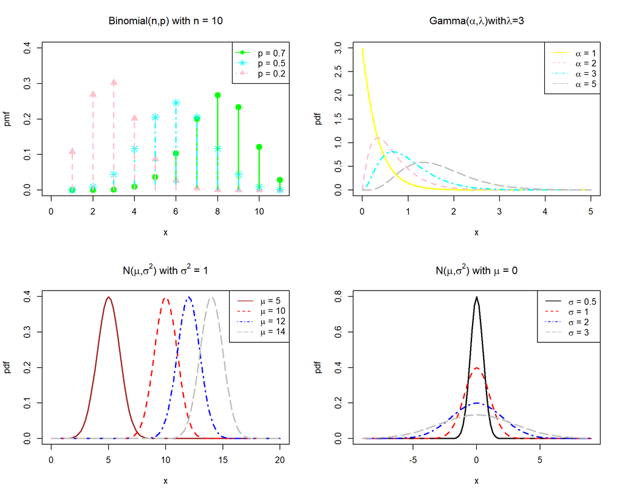

### 期末考的愛心圖

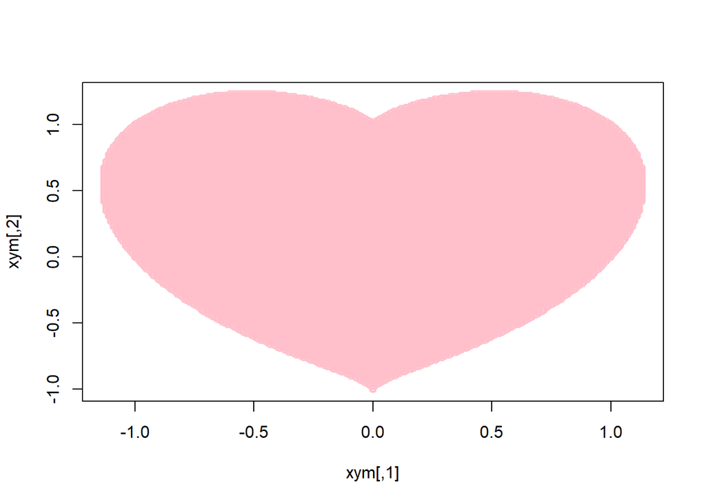

```r
x <- seq(-1.5, 1.5, 0.01); y <- seq(-1.5, 1.5, 0.01)
xyvector <- c()
for (i in 1:length(x)){
  for (j in 1:length(y)){
    cond <- (x[i]^2)*(y[j]^3) - (x[i]^2 + y[j]^2 - 1)^3
    if (cond >= 0) {
      xyvector <- c(xyvector,x[i],y[j])
    }
  }
}
xym <- matrix(xyvector, ncol = 2, byrow = TRUE)
plot(xym,
     type = "p",
     col = "pink")
```

```r
library("titanic")   #以鐵達尼號為例
data(titanic_train)
tdata <- titanic_train   #為鐵達尼號的資料設定變數
people <- length(tdata[,1])   #人數

##然後就是dummy variable的function了##
dummy <- function(d){
  kinds <- unique(d)   #輸入項為data的其中一個變數，在此提取該變數的向量
  dumvector <- c()
  for (i in 1:people){
    for (j in 1:length(kinds)){
      if (d[i] == kinds[j]) {
        dumvector <- c(dumvector,1)
      } else {
        dumvector <- c(dumvector,0)
      }
    }
  }
  result <- matrix(dumvector,nrow = people, ncol = length(kinds))
  colnames(result) <- kinds
  return(result)
}
```

## 到這裡可以稍微看看就直接拉到底了

```r
dummy(tdata$Sex)  #以性別為例
```

```
##        male female
##   [1,]    1      0
##   [2,]    0      0
##   [3,]    0      1
##   [4,]    1      1
##   [5,]    0      0
##   [6,]    1      0
##   [7,]    0      1
##   [8,]    1      1
##   [9,]    1      0
##  [10,]    0      1
##  [11,]    1      0
##  [12,]    0      1
##  [13,]    1      0
##  [14,]    0      1
```

[output cut: 877 more lines]

### 上個學期的r課程，功課非常簡單，但考試超難，而在考試中學到的也比平常複習、寫作業來的多，可以說是每經過一次考試，我的r語言能力就大幅增長，所以這個作業我放了不少考試的內容。最後再做一個總結吧，比起語法，我學到更多的是r與python的不同之處，像是python是從0開始算的程式語言，r則是1，光是這點，若一不小心將python的語言邏輯套用在r上的話，就有許多需要debug的地方了。以上，就是我對上學期r課程的複習與回顧。